# Week 5 lab BST 210

Daniel Herrera, Willow Duffell, Lauren Mock

10/9/2021

#### *Group 4 Members:*

Daniel Herrera  
Willow Duffell  
Lauren Mock

## Question 1

**General area/domain/subject area**

The general subject area of this project is bone marrow transplant outcomes in children with hematologic diseases.

## Question 2

**Dataset and source**

We will use data obtained from the UCI Machine Learning Repository: Center for Machine Learning and Intelligent Systems that was originally collected by researchers in the Faculty of Automatic Control, Electronics and Computer Science at Silesian University of Technology in Poland. This data set includes children with hematologic diseases, such as leukemia, who underwent bone marrow transplants. It includes information on the donor, the recipient, and the recipient’s response to the treatment.

The source of this data set can be found here: https://archive.ics.uci.edu/ml/datasets/Bone+marrow+transplant%3A+children

And a downloadable version of the data set can be found here: https://www.kaggle.com/adamgudys/bone-marrow-transplant-children

## Question 3

**Primary questions**

Our primary goals are to predict (before transplantation) whether or not a patient will survive, and to understand which factors are the most important in determining survival. We are particularly interested in determining the importance of the closeness of the match between the recipient and the donor for survival.

## Question 4

**Secondary questions**

There is a lot of controversy around the source of hematopoietic stem cells used in transplantation (either peripheral blood (PBSC) or bone marrow (BM)). It would be interesting to see if there is an association between these two stem-cell sources and the likelihood of survival, and we will definitely need to be careful with confounding when addressing this question.

## Question 5

**Outcome(s)/endpoint(s)**

Our primary outcome is survival status at the end of the follow-up period, which is a binary variable. We are interested in predicting a patient’s probability of survival, as well as understanding the relative importance of factors that influence survival.

## Question 6

**Draft Statistical Analysis Plan**

*I. Explain important variables (using “domain” knowledge)*

1. Identify potential confounders and effect measure modifiers (EMM)
2. Will require an understanding of how our variables are associated

*II. Exploratory Data Analysis (EDA using above)*

1. Visualizations (scatterplots - with jitter since survival 0-1, correlation matrices)
2. Visualize confounding and EMM Summary statistics

*III. Candidate Variables*

1. Choose best variables to use to predict survival

*IV. Model Selection*

1. Primary Question

Prediction of survival

1. Goal is to predict survival at end of follow-up (binary variable)
2. Does not need to account for confounding, because we only want the best possible prediction of survival
3. Perform logistic regression (binary outcome) with all variables that may be important
   - Trim model - remove unnecessary variables to avoid unnecessary complexity/overfitting
   - Backwards removal using adjusted R^2 (since we are more concerned with maximizing our predictive ability–the amount of variability in y explained by our covariates)
4. Explore K-means as a non-parametric method of predicting survival

Determining Risk Factors for Mortality (Association)

1. Goal is to determine the most important risk factors in determining whether or not a patient survives
   - This will only include data that is collected before transplantation
2. Must account for confounding, because we care about the strength of the relationship between each variable and survival
3. Perform logistic regression with all variables that may be important
   - Trim model - remove unnecessary variables to avoid unnecessary complexity/overfitting
   - Backwards removal using adjusted R^2 (since we are more concerned with maximizing our predictive ability–the amount of variability in y explained by our covariates)
2. Secondary Question–Source of hematopoietic stem cells
   1. Goal is to determine association between the two stem-cell source methods (peripheral blood and bone marrow) and their outcome of survival, presumably using the relevant covariates discovered in our model above
   2. Confounders will be important here, since we don’t yet know which type of patients receive which treatment
   3. Using Association model results from our primary question, add variable stem_cell_source and run an ANOVA test to determine which source has a better outcome of survival

*V. Check for multicollinearity using variance inflation factors*

1. We expect many of our variables to be highly correlated

*VI. Validate model using Cross-Validation, where appropriate*

1. Samples of the training/testing data
2. How well would the prediction model perform on other data?

*VII. Run sensitivity analysis using Ridge, LASSO, or Elastic Net*

## Question 7

**Biggest challenges foreseen**

One of the main challenges we foresee in answering our proposed questions is our lack of subject matter knowledge. In addressing which risk factors are most important in determining survival, we will need to have a comprehensive understanding of the potential confounders in our data set to ensure that the coefficients in our models are meaningful. In our secondary analysis, we will need to understand why a patient may be selected for a bone marrow transplant vs. a peripheral blood transplant, which will require a domain expert. We will also need to account for the many variable types included in our data, including numeric, categorical, and indicator.

## Question 8

**Domain expertise sought**

We will need to find a domain expert who has experience with hematologic diseases or bone marrow transplants in order to better understand our dataset and its variables. This will be especially important in identifying potential confounders, which cannot be identified through any statistical process alone. This will also give us some insight into possible effect measure modifiers. For now, we have discussed our dataset with Daniel’s fiancee, who is a doctor, and Willow’s mom, who is a nurse practitioner. Moving forward, we will be seeking additional expertise.

## Question 9

**What software package(s) will you use to complete this project?**

We will all be using R.

## Question 10

**Complete an initial round of exploratory analyses on your data that would be relevant to your plan and responses above, and include any plots, summaries, code and output. Please include exploratory analysis for outcome(s) of continuous form however/wherever possible even if your ultimate goals/questions involve a different form of outcome data such as binary, polytomous, etc. (You may consider this initial analysis as a potential sub-analysis later on.)**

### Explore Missing Values

Before we begin with any visualizations and summary statistics, we would like to explore missing-ness within our data set.

```r
# lets look at a table of all missing values
colSums(is.na(bone))
```

```
##                      donor_age             donor_age_below_35
##                              0                              0
##                      donor_ABO                      donor_CMV
##                              0                              0
##                  recipient_age         recipient_age_below_10
##                              0                              0
##              recipient_age_int               recipient_gender
##                              0                              0
##            recipient_body_mass                  recipient_ABO
##                              0                              0
##                   recipient_rh                  recipient_CMV
##                              0                              0
##                        disease                  disease_group
##                              0                              0
##                   gender_match                      ABO_match
##                              0                              0
##                     CMV_status          HLA_match..out.of.10.
##                              0                              0
##                  HLA_match_raw                   HLA_mismatch
##                              0                              0
##                        antigen                         allele
##                              0                              0
##                    HLA_group_1                     risk_group
##                              0                              0
##               stem_cell_source                tx_post_relapse
##                              0                              0
## CD34_x1e6_per_kg...CD34kgx10d6                CD3_x1e8_per_kg
##                              0                              0
##              CD3_to_CD34_ratio                   ANC_recovery
##                              0                              0
##                   PLT_recovery           acute_GvHD_II_III_IV
##                              0                              0
##              acute_GvHD_III_IV      time_to_acute_GvHD_III_IV
##                              0                              0
##         extensive_chronic_GvHD                        relapse
##                              0                              0
##                  survival_time                survival_status
##                              0                              0
```

Great, no missing data (spoiler: there is). Oh wait, there are “?” marks that we should examine. We see that there are actually a bit of “?” in our data set, so this may need to be addressed later, particularly for variables such as recipient CMV (14 ?’s), CMV_status (16) and extensive_chronic_GvHD (31 ?’s). For now, we will replace the “?”s in the data set.

```r
# let us see the number of ?'s that appear
sort(colSums(bone == "?"), decreasing = TRUE) [1:10]
```

```
## extensive_chronic_GvHD             CMV_status          recipient_CMV
##                     31                     16                     14
##        CD3_x1e8_per_kg      CD3_to_CD34_ratio              donor_CMV
##                      5                      5                      2
##    recipient_body_mass           recipient_rh          recipient_ABO
##                      2                      2                      1
##              ABO_match
##                      1
```

```r
# replace ?'s with true NA's
bone <- mutate_all(bone, ~replace(., . == "?", NA))

# Now we can see all of the ?'s have been replaced with NA values that are picked up
sort(colSums(is.na(bone)), decreasing = TRUE) [1:10]
```

```
## extensive_chronic_GvHD             CMV_status          recipient_CMV
##                     31                     16                     14
##        CD3_x1e8_per_kg      CD3_to_CD34_ratio              donor_CMV
##                      5                      5                      2
##    recipient_body_mass           recipient_rh          recipient_ABO
##                      2                      2                      1
##              ABO_match
##                      1
```

Well, it turns out there are some other problematic values. Some time-to-event variables have entries of 1,000,000, which will be challenging to handle in our EDA.

To illustrate, let us see the number of occurrences of the value 1000000. This value frequently occurs in the data amongst three variables. It seems as though these large values indicate that the event never occurred for that subject, but we will need to confirm this. If our assumption is correct, then we will need to seek out advice on how to proceed.

For now, we will leave these values as is. We don’t want to replace them with NA, because they do not appear to be missing values.

```r
# let us see the number of ?'s that appear
sort(colSums(bone == "1000000"), decreasing = TRUE) [1:3]
```

```
## time_to_acute_GvHD_III_IV              PLT_recovery              ANC_recovery
##                       145                        17                         5
```

```r
# replace with NA
# bone <- mutate_all(bone, ~replace(., . == "1000000", NA))
```

Let’s also make sure our true missing values do not exceed 5% of each column.

```r
# look of missing values as % of column
missing_vals <- bone %>%
  is.na() %>%
  colSums() %>%
  `/`(nrow(bone)) %>%
  `*`(100)

missing_vals[missing_vals >= 5] %>% names()
```

```
## [1] "recipient_CMV"          "CMV_status"             "extensive_chronic_GvHD"
```

Only these three columns have > 5% missing values. We will need to investigate these missing values later if we choose to use these variables in our analysis.

### Basic Data Exploration

Now we can explore some more standard EDA. Let’s familiarize ourselves with the data set by briefly viewing all the columns, column types, a brief amount of data. We can then explore summary statistics. Note: we will have to change some of our data from character data to numeric data.

#### Numerical Variables:

donor_age, recipient_age, recipient_body_mass, CD34_x1e6_per_kg…CD34kgx10d6, CD3_x1e8_per_kg, CD3_to_CD34_ratio, ANC_recovery, PLT_recovery, time_to_acute_GvHD_III_IV, survival_time

#### Categorical Variables:

donor_ABO, recipient_age_int, recipient_ABO, disease, CMV_status, HLA_match..out.of.10., antigen, allele, HLA_group_1

#### Binary Variables:

donor_age_below_35 (yes/no), donor_CMV (present/absent), recipient_age_below_10 (yes/no), recipient_rh (plus/minus), recipient_CMV (present/absent), disease_group (malignant/nonmalignant), gender_match(female_to_male/other), ABO_match (matched/mismatched), HLA_mismatch (matched, mismatched), risk_group (high/low), stem_cell_source (peripheral_blood/bone_marrow),tx_post_relapse (yes/no), acute_GvHD_II_III_IV (yes/no), acute_GvHD_III_IV (yes/no), extensive_chronic_GvHD (yes/no), relapse (yes/no), survival_status (yes,no)

```r
glimpse(bone)
```

```
## Rows: 187
## Columns: 38
## $ donor_age                      <dbl> 22.83014, 23.34247, 26.39452, 39.68493,~
## $ donor_age_below_35             <chr> "yes", "yes", "yes", "no", "yes", "yes"~
## $ donor_ABO                      <chr> "A", "B", "B", "A", "A", "AB", "0", "0"~
## $ donor_CMV                      <chr> "present", "absent", "absent", "present~
## $ recipient_age                  <dbl> 9.6, 4.0, 6.6, 18.1, 1.3, 8.9, 14.4, 18~
## $ recipient_age_below_10         <chr> "yes", "yes", "yes", "no", "yes", "yes"~
## $ recipient_age_int              <chr> "5_10", "0_5", "5_10", "10_20", "0_5", ~
## $ recipient_gender               <chr> "male", "male", "male", "female", "fema~
## $ recipient_body_mass            <chr> "35", "20.6", "23.4", "50", "9", "40", ~
## $ recipient_ABO                  <chr> "A", "B", "B", "AB", "AB", "0", "A", "A~
## $ recipient_rh                   <chr> "plus", "plus", "plus", "plus", "minus"~
## $ recipient_CMV                  <chr> "present", "absent", "present", "absent~
## $ disease                        <chr> "ALL", "ALL", "ALL", "AML", "chronic", ~
```

[output cut: 25 more lines]

### Explore donor data

```r
summary(bone$donor_age)
```

```
##    Min. 1st Qu.  Median    Mean 3rd Qu.    Max.
##   18.65   27.04   33.55   33.47   40.12   55.55
```

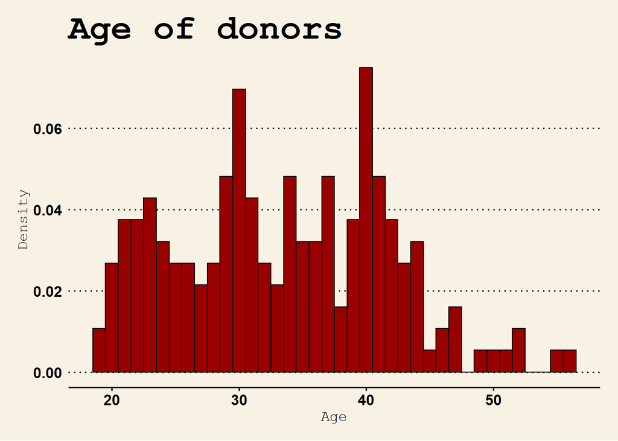

```r
# plot histogram of age distribution
ggplot(bone) +
  geom_histogram(aes(x = donor_age, y = ..density..), fill = "#990000", col = "black", binwidth = 1) +
  ggtitle("Age of donors", ) +
  xlab("Age") +
  ylab("Density") +
  theme_wsj()+ theme(axis.title=element_text(size=12))
```

```r
# summary stats for donor blood type
bone %>%
  group_by(donor_ABO) %>%
  summarise(n = length(donor_ABO),
            proportion = length(donor_ABO)/nrow(bone))
```

```
## # A tibble: 4 x 3
##   donor_ABO     n proportion
##   <chr>     <int>      <dbl>
## 1 0            73     0.390
## 2 A            71     0.380
## 3 AB           15     0.0802
## 4 B            28     0.150
```

```r
# summary stats for donor cytomegalovirus status
bone %>%
  group_by(donor_CMV) %>%
  summarise(n = length(donor_CMV),
            proportion = length(donor_CMV)/nrow(bone))
```

```
## # A tibble: 3 x 3
##   donor_CMV     n proportion
##   <chr>     <int>      <dbl>
## 1 absent      113     0.604
## 2 present      72     0.385
## 3 <NA>          2     0.0107
```

### Explore recipient data

```r
summary(bone$recipient_age)
```

```
##    Min. 1st Qu.  Median    Mean 3rd Qu.    Max.
##   0.600   5.050   9.600   9.932  14.050  20.200
```

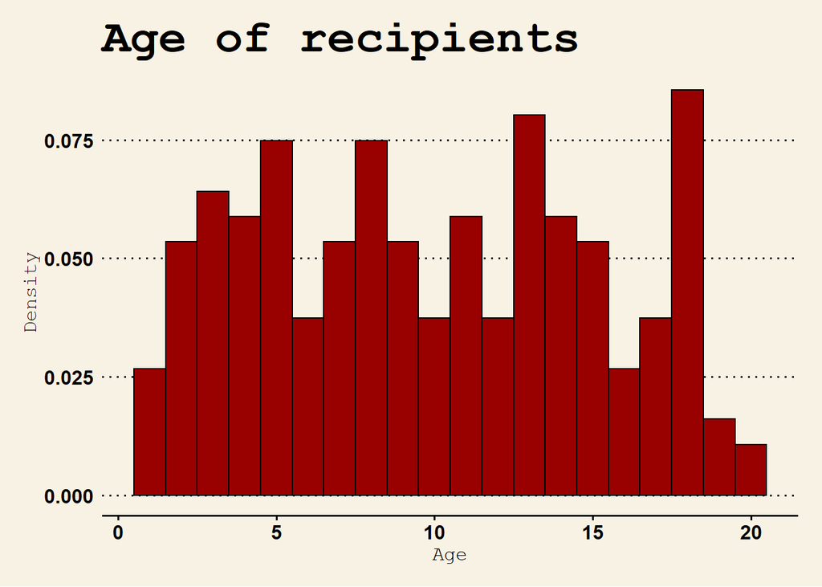

```r
# plot histogram of age distribution
bone %>%
ggplot() +
  geom_histogram(aes(x = recipient_age, y=..density..), fill = "#990000", col = "black", binwidth = 1) +
  ggtitle("Age of recipients" ) +
  xlab("Age") +
  ylab("Density") +
  theme_wsj()+ theme(axis.title=element_text(size=12))
```

```r
# summary stats for blood type
bone %>%
  group_by(recipient_ABO) %>%
  summarise(n = length(recipient_ABO),
            proportion = length(recipient_ABO)/nrow(bone))
```

```
## # A tibble: 5 x 3
##   recipient_ABO     n proportion
##   <chr>         <int>      <dbl>
## 1 0                48    0.257
## 2 A                75    0.401
## 3 AB               13    0.0695
## 4 B                50    0.267
## 5 <NA>              1    0.00535
```

```r
# summary stats for recipient cytomegalovirus status
bone %>%
  group_by(recipient_CMV) %>%
  summarise(n = length(recipient_CMV),
            proportion = length(recipient_CMV)/nrow(bone))
```

```
## # A tibble: 3 x 3
##   recipient_CMV     n proportion
##   <chr>         <int>      <dbl>
## 1 absent           73     0.390
## 2 present         100     0.535
## 3 <NA>             14     0.0749
```

So far we can see the following:

1. Our recipients are mostly between 5 and 15 years old (min age is 0.6 years old and max age is 20 years old)
2. Recipients’ blood types are as follows: type O (25.7%), type A (40.1%), type AB (7.0%), B (26.7%), NA (0.5%)
3. Recipients’ cytomegalovirus status follows: absent (39.0%), present (53.5%), missing (7.5%)

Now we can try to have a look at recipients’ weight, rh factor (+ or -), and risk group.

Note: Changed data type of recipient body mass from character to numeric (Assuming weight has units of lbs)

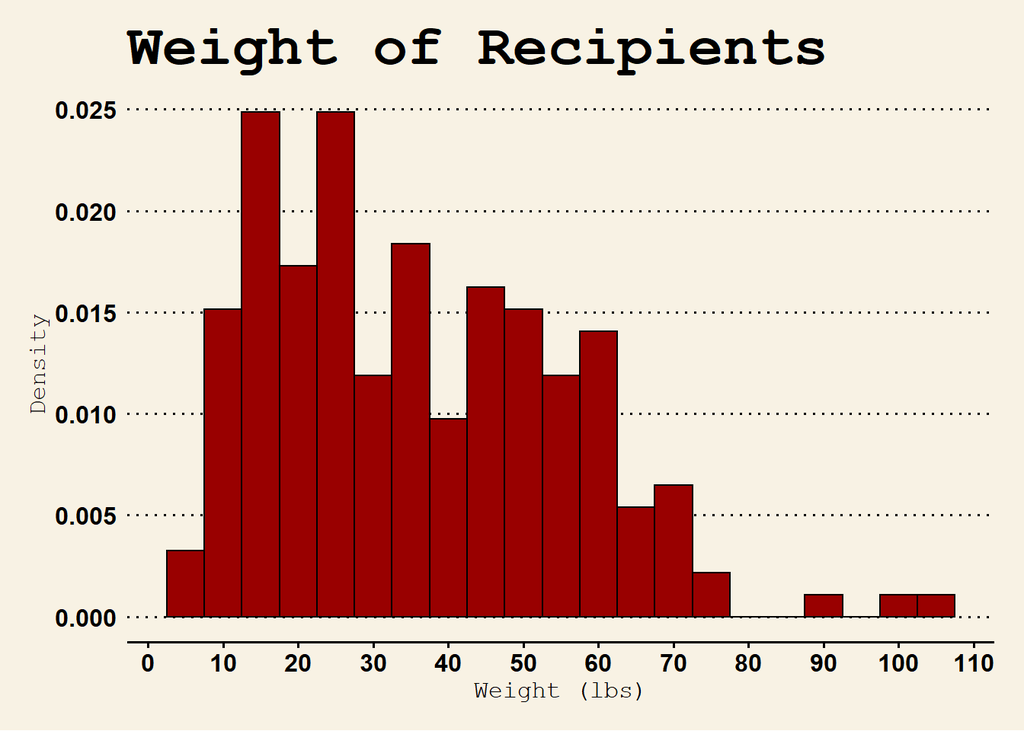

```r
# plot histogram of body mass distribution
bone %>%
ggplot() +
  geom_histogram(aes(x = as.numeric(recipient_body_mass), y = ..density..),
                 fill = "#990000", col = "black", binwidth = 5) +
  ggtitle("Weight of Recipients", ) +
  scale_x_continuous(breaks = seq(0, 110, by =10)) +
  xlab("Weight (lbs)") +
  ylab("Density") +
  theme_wsj()+ theme(axis.title=element_text(size=12))
```

```r
# summary stats for recipient rh factor
bone %>%
  group_by(recipient_rh) %>%
  summarise(n = length(recipient_rh),
            proportion = length(recipient_rh)/nrow(bone))
```

```
## # A tibble: 3 x 3
##   recipient_rh     n proportion
##   <chr>        <int>      <dbl>
## 1 minus           27     0.144
## 2 plus           158     0.845
## 3 <NA>             2     0.0107
```

```r
# summary stats for recipient risk group
bone %>%
  group_by(risk_group) %>%
  summarise(n = length(risk_group),
            proportion = length(risk_group)/nrow(bone))
```

```
## # A tibble: 2 x 3
##   risk_group     n proportion
##   <chr>      <int>      <dbl>
## 1 high          69      0.369
## 2 low          118      0.631
```

So far we can see the following about our recipients:

1. Our recipients weighed between 15lbs to 60lbs (min weight is 6 lbs and max weight is 103.4 lbs)
2. Recipients’ rh factor (rhesus) are as follows: plus (84.5%), minus (14.4%), NA (1.1%)
3. Risk status follows: high (36.9%), low (63.1%)

### Scatterplots

Looking only at the numerical variables next:

```r
bone_num <- bone %>% select(c(donor_age, recipient_age, recipient_body_mass, CD34_x1e6_per_kg...CD34kgx10d6, CD3_x1e8_per_kg, CD3_to_CD34_ratio, ANC_recovery, PLT_recovery, time_to_acute_GvHD_III_IV, survival_time, survival_status))

bone_num <- sapply(bone_num, as.numeric)
```

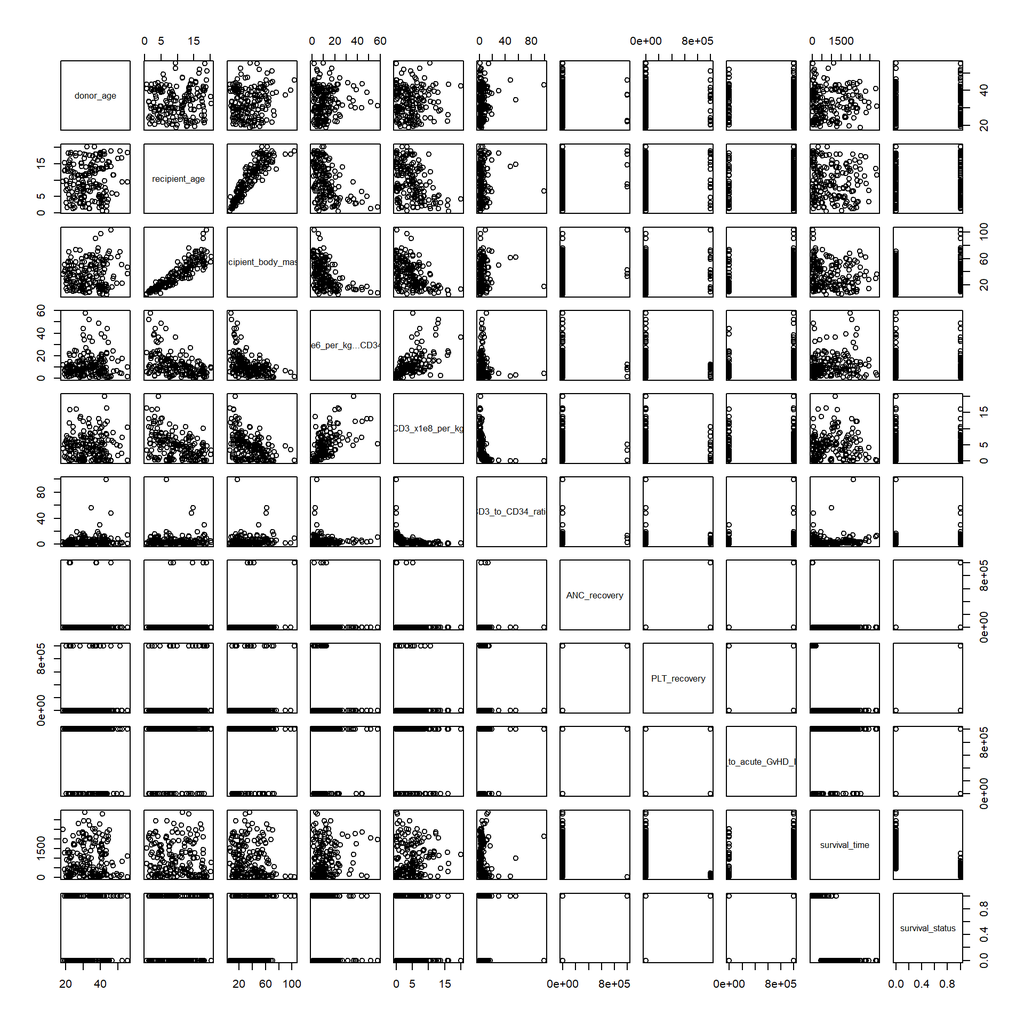

```r
pairs(bone_num)
```

We see at first glance based off of the correlation scatter plots that recipient age and body mass are very highly correlated (as we would expect). We also see many plots with binary variables, and several plots with points that are very far from the main cloud of data.

We can also use a correlation matrix to see the relationships between our variables, where applicable. The data is quite large with many binary variables, so perhaps our visualizations will aid us more effectively.

```r
# correlation matrix
cor(bone_num, use= "complete.obs") %>% as.data.frame() %>% pander()
```

Table continues below

|  | donor_age | recipient_age |
| --- | --- | --- |
| **donor_age** | 1 | 0.108 |
| **recipient_age** | 0.108 | 1 |
| **recipient_body_mass** | 0.1172 | 0.8992 |
| **CD34_x1e6_per_kg…CD34kgx10d6** | 0.07269 | -0.4491 |
| **CD3_x1e8_per_kg** | 0.02355 | -0.4307 |
| **CD3_to_CD34_ratio** | 0.1449 | 0.05391 |
| **ANC_recovery** | 0.04305 | 0.1001 |
| **PLT_recovery** | -0.0366 | 0.09522 |
| **time_to_acute_GvHD_III_IV** | 0.004617 | 0.1516 |
| **survival_time** | -0.007969 | -0.1256 |
| **survival_status** | 0.07668 | 0.1925 |

Table continues below

|  | recipient_body_mass |
| --- | --- |
| **donor_age** | 0.1172 |
| **recipient_age** | 0.8992 |
| **recipient_body_mass** | 1 |
| **CD34_x1e6_per_kg…CD34kgx10d6** | -0.4657 |
| **CD3_x1e8_per_kg** | -0.4536 |
| **CD3_to_CD34_ratio** | 0.06139 |
| **ANC_recovery** | 0.1389 |
| **PLT_recovery** | 0.1245 |
| **time_to_acute_GvHD_III_IV** | 0.1447 |
| **survival_time** | -0.1408 |
| **survival_status** | 0.2337 |

Table continues below

|  | CD34_x1e6_per_kg…CD34kgx10d6 |
| --- | --- |
| **donor_age** | 0.07269 |
| **recipient_age** | -0.4491 |
| **recipient_body_mass** | -0.4657 |
| **CD34_x1e6_per_kg…CD34kgx10d6** | 1 |
| **CD3_x1e8_per_kg** | 0.5833 |
| **CD3_to_CD34_ratio** | -0.1306 |
| **ANC_recovery** | -0.0835 |
| **PLT_recovery** | -0.1811 |
| **time_to_acute_GvHD_III_IV** | 0.003353 |
| **survival_time** | 0.1583 |
| **survival_status** | -0.1633 |

Table continues below

|  | CD3_x1e8_per_kg | CD3_to_CD34_ratio |
| --- | --- | --- |
| **donor_age** | 0.02355 | 0.1449 |
| **recipient_age** | -0.4307 | 0.05391 |
| **recipient_body_mass** | -0.4536 | 0.06139 |
| **CD34_x1e6_per_kg…CD34kgx10d6** | 0.5833 | -0.1306 |
| **CD3_x1e8_per_kg** | 1 | -0.3709 |
| **CD3_to_CD34_ratio** | -0.3709 | 1 |
| **ANC_recovery** | -0.09975 | 0.02466 |
| **PLT_recovery** | -0.1132 | -0.01089 |
| **time_to_acute_GvHD_III_IV** | -0.03535 | 0.03024 |
| **survival_time** | 0.06099 | 0.04402 |
| **survival_status** | -0.2323 | 0.08987 |

Table continues below

|  | ANC_recovery | PLT_recovery |
| --- | --- | --- |
| **donor_age** | 0.04305 | -0.0366 |
| **recipient_age** | 0.1001 | 0.09522 |
| **recipient_body_mass** | 0.1389 | 0.1245 |
| **CD34_x1e6_per_kg…CD34kgx10d6** | -0.0835 | -0.1811 |
| **CD3_x1e8_per_kg** | -0.09975 | -0.1132 |
| **CD3_to_CD34_ratio** | 0.02466 | -0.01089 |
| **ANC_recovery** | 1 | 0.4829 |
| **PLT_recovery** | 0.4829 | 1 |
| **time_to_acute_GvHD_III_IV** | 0.08084 | -0.06482 |
| **survival_time** | -0.1671 | -0.3247 |
| **survival_status** | 0.1674 | 0.3467 |

Table continues below

|  | time_to_acute_GvHD_III_IV | survival_time |
| --- | --- | --- |
| **donor_age** | 0.004617 | -0.007969 |
| **recipient_age** | 0.1516 | -0.1256 |
| **recipient_body_mass** | 0.1447 | -0.1408 |
| **CD34_x1e6_per_kg…CD34kgx10d6** | 0.003353 | 0.1583 |
| **CD3_x1e8_per_kg** | -0.03535 | 0.06099 |
| **CD3_to_CD34_ratio** | 0.03024 | 0.04402 |
| **ANC_recovery** | 0.08084 | -0.1671 |
| **PLT_recovery** | -0.06482 | -0.3247 |
| **time_to_acute_GvHD_III_IV** | 1 | 0.127 |
| **survival_time** | 0.127 | 1 |
| **survival_status** | -0.09932 | -0.7567 |

|  | survival_status |
| --- | --- |
| **donor_age** | 0.07668 |
| **recipient_age** | 0.1925 |
| **recipient_body_mass** | 0.2337 |
| **CD34_x1e6_per_kg…CD34kgx10d6** | -0.1633 |
| **CD3_x1e8_per_kg** | -0.2323 |
| **CD3_to_CD34_ratio** | 0.08987 |
| **ANC_recovery** | 0.1674 |
| **PLT_recovery** | 0.3467 |
| **time_to_acute_GvHD_III_IV** | -0.09932 |
| **survival_time** | -0.7567 |
| **survival_status** | 1 |

### Compare outcome variable (survival_status) and numeric variables

1. Explore our binary outcome variable

In order to explore our outcome variable of interest, survival status after bone marrow transplant, we must first change it to numeric. This graph shows us that 45.5% of our bone marrow transplant patients unfortunately did not survive, while 54.5% did survive.

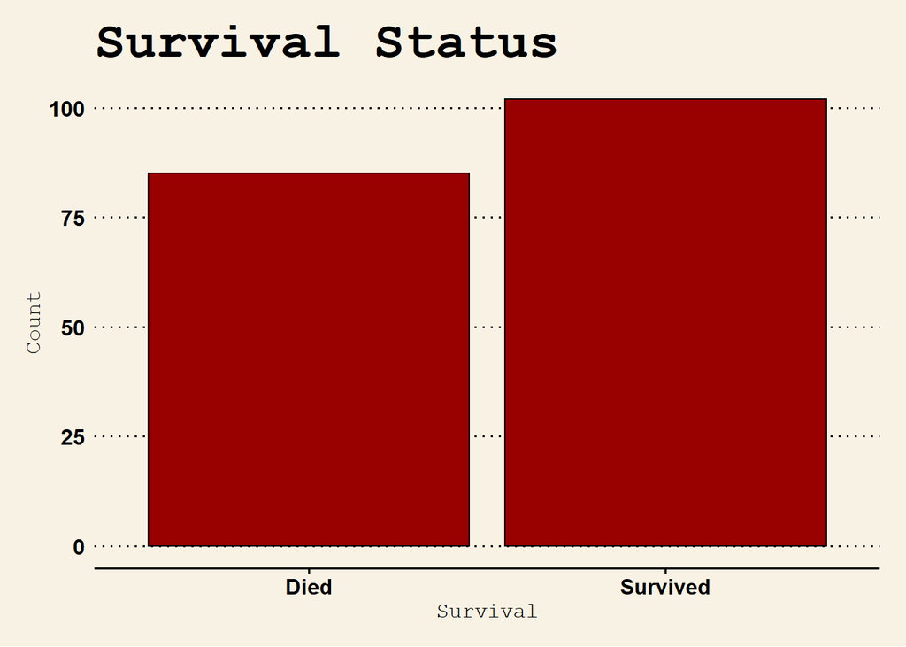

```r
bone$survival_status <- ifelse(bone$survival_status == 1, "Died", "Survived") %>% as.factor()

bone %>%
ggplot(aes(x = survival_status)) +
  geom_histogram(fill = "#990000", col = "black", binwidth = 5, stat = "count") +
  ggtitle("Survival Status", ) +
  xlab("Survival") +
  ylab("Count") +
  theme_wsj()+ theme(axis.title=element_text(size=12))
```

```r
bone %>%
  group_by(survival_status) %>%
  summarise(n = length(survival_status),
            proportion = length(survival_status)/nrow(bone))
```

```
## # A tibble: 2 x 3
##   survival_status     n proportion
##   <fct>           <int>      <dbl>
## 1 Died               85      0.455
## 2 Survived          102      0.545
```

2. Look at binary outcome with continuous predictors

Now let’s view our outcome variable, survival status, with our continuous predictor variables (listed below). We should pay close attention to any notable changes in distributions between those who survived compared to those who did not.

donor_age, recipient_age, recipient_body_mass, CD34_x1e6_per_kg…CD34kgx10d6, CD3_x1e8_per_kg, CD3_to_CD34_ratio, ANC_recovery, PLT_recovery, time_to_acute_GvHD_III_IV, survival_time

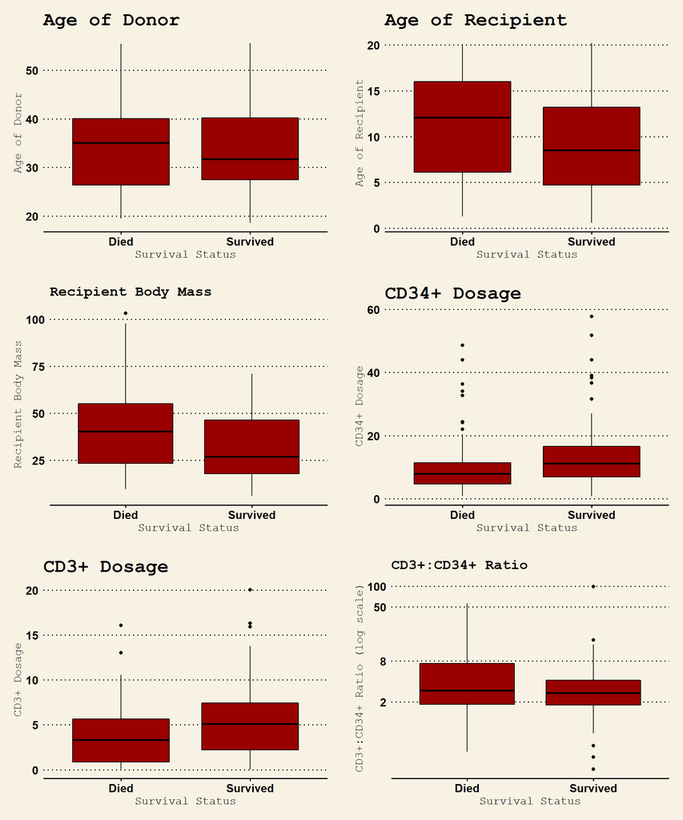

```r
# construct plots of continuous predictors
c1 <- bone %>%
  ggplot(aes(x = survival_status, y = donor_age)) +
  geom_boxplot(fill = "#990000", col = "black") +
  ggtitle("Age of Donor") +
  xlab("Survival Status") +
  ylab("Age of Donor") +
  theme_wsj()+ theme(axis.title=element_text(size=12),
                     plot.title = element_text(size = 20))


c2 <- bone %>%
  ggplot(aes(x = survival_status, y = recipient_age)) +
  geom_boxplot(fill = "#990000", col = "black") +
  ggtitle("Age of Recipient") +
  xlab("Survival Status") +
  ylab("Age of Recipient") +
  theme_wsj()+ theme(axis.title=element_text(size=12),
                     plot.title = element_text(size = 20))


c3 <- bone %>%
  ggplot(aes(x = survival_status, y = as.numeric(recipient_body_mass))) +
  geom_boxplot(fill = "#990000", col = "black") +
  ggtitle("Recipient Body Mass") +
  xlab("Survival Status") +
  ylab("Recipient Body Mass") +
  theme_wsj()+ theme(axis.title=element_text(size=12),
                     plot.title = element_text(size = 15))


c4 <- bone %>%
  ggplot(aes(x = survival_status, y = as.numeric(CD34_x1e6_per_kg...CD34kgx10d6))) +
  geom_boxplot(fill = "#990000", col = "black") +
  ggtitle("CD34+ Dosage") +
  xlab("Survival Status") +
  ylab("CD34+ Dosage") +
  theme_wsj()+ theme(axis.title=element_text(size=12),
                     plot.title = element_text(size = 20))


c5 <- bone %>%
  ggplot(aes(x = survival_status, y = as.numeric(CD3_x1e8_per_kg))) +
  geom_boxplot(fill = "#990000", col = "black") +
  ggtitle("CD3+ Dosage") +
  xlab("Survival Status") +
  ylab("CD3+ Dosage") +
  theme_wsj()+ theme(axis.title=element_text(size=12),
                     plot.title = element_text(size = 20))


c6 <- bone %>%
  ggplot(aes(x = survival_status, y = as.numeric(CD3_to_CD34_ratio))) +
  geom_boxplot(fill = "#990000", col = "black") +
  scale_y_continuous(trans = "log", breaks = c(2,8,50,100)) +
  ggtitle("CD3+:CD34+ Ratio") +
  xlab("Survival Status") +
  ylab("CD3+:CD34+ Ratio (log scale)") +
  theme_wsj()+ theme(axis.title=element_text(size=12),
                     plot.title = element_text(size = 15))

# plot together
grid.arrange(c1,c2,c3,c4,c5,c6, ncol = 2, nrow = 3)
```

We can observe above the various relationships our variables have with the survival status outcome variable. I can not tell regression outcomes just from graphs, but we are particularly interested in variables such as CD34+ Dosage and CD3+ Dosage which tell us the amount of bone marrow transplanted.

### Comparison of Outcome (survival_status) and categorical variables

First, we will look at the comparison between our outcome variable and the different categorical variables which include:

#### Categorical Variables:

donor_ABO, recipient_age_int, recipient_ABO, disease, CMV_status, HLA_match..out.of.10., antigen, allele and HLA_group_1

```r
par(mfrow=c(3,3))

#Donor ABO
#2x2 table with margins
tab1 <- table(bone$survival_status,bone$donor_ABO)
tab1 <-prop.table(tab1,2)
addmargins(tab1) %>% pander(caption = "Donor Blood Type")
```

Donor Blood Type

|  | 0 | A | AB | B | Sum |
| --- | --- | --- | --- | --- | --- |
| **Died** | 0.4521 | 0.507 | 0.2667 | 0.4286 | 1.654 |
| **Survived** | 0.5479 | 0.493 | 0.7333 | 0.5714 | 2.346 |
| **Sum** | 1 | 1 | 1 | 1 | 4 |

```r
barplot(tab1,
        xlab='Donor Blood Type',
        ylab='Survival = Yellow, Death = Red',
        main="Survival by Donor Blood Type",
        col=c("#990000","yellow"),
        cex.main = 1,
        legend=rownames(tab1),
        args.legend=list(x="topleft"), beside=T)



#Recipient age
bone$recipient_age_int <- factor(bone$recipient_age_int , levels=c("0_5", "5_10", "10_20"))
#2x2 table with margins
tab2 <- table(bone$survival_status,bone$recipient_age_int)
tab2 <-prop.table(tab2,2)
addmargins(tab2) %>% pander(caption = "Recipient Age")
```

Recipient Age

|  | 0_5 | 5_10 | 10_20 | Sum |
| --- | --- | --- | --- | --- |
| **Died** | 0.3617 | 0.4118 | 0.5281 | 1.302 |
| **Survived** | 0.6383 | 0.5882 | 0.4719 | 1.698 |
| **Sum** | 1 | 1 | 1 | 3 |

```r
barplot(tab2,
        xlab='Recipient Age Range',
        ylab='Survival = Yellow, Death = Red',
        main="Survival by Recipient Age Range",
        cex.main = 1,
        col=c("#990000","yellow"),
        legend=rownames(tab2),
        args.legend=list(x="topleft"), beside=T)



#recipient_ABO
#2x2 table with margins
tab3 <- table(bone$survival_status,bone$recipient_ABO)
tab3 <-prop.table(tab3,2)
addmargins(tab3) %>% pander(caption = "Recipient Blood Type")
```

Recipient Blood Type

|  | 0 | A | AB | B | Sum |
| --- | --- | --- | --- | --- | --- |
| **Died** | 0.4375 | 0.48 | 0.3846 | 0.44 | 1.742 |
| **Survived** | 0.5625 | 0.52 | 0.6154 | 0.56 | 2.258 |
| **Sum** | 1 | 1 | 1 | 1 | 4 |

```r
barplot(tab3,
        xlab='Recipient Blood Type',
        ylab='Survival = Yellow, Death = Red',
        main="Survival by Recipient Blood Type",
        col=c("#990000","yellow"),
        cex.main = 1,
        legend=rownames(tab3),
        args.legend=list(x="topleft"), beside=T)



#Disease
#2x2 table with margins
# disease by survival
tab4 <- table(bone$survival_status,bone$disease)
tab4 <-prop.table(tab4,2)
addmargins(tab4) %>% pander(caption = "Disease")
```

Disease

|  | ALL | AML | chronic | lymphoma | nonmalignant | Sum |
| --- | --- | --- | --- | --- | --- | --- |
| **Died** | 0.4412 | 0.4545 | 0.4222 | 1 | 0.375 | 2.693 |
| **Survived** | 0.5588 | 0.5455 | 0.5778 | 0 | 0.625 | 2.307 |
| **Sum** | 1 | 1 | 1 | 1 | 1 | 5 |

```r
barplot(tab4,
        ylab='Survival = Yellow, Death = Red',
        main="Survival by Recipient Disease",
        cex.main = 1,
        las = 2,
        col=c("#990000","yellow"),
        legend=rownames(tab4),args.legend=list(x="topleft"), beside=T)



#CMV_status

#2x2 table with margins
# CMV status by survival
tab5 <- table(bone$survival_status,bone$CMV_status)
tab5 <-prop.table(tab5,2)
addmargins(tab5) %>% pander(caption = "CMV Status")
```

CMV Status

|  | 0 | 1 | 2 | 3 | Sum |
| --- | --- | --- | --- | --- | --- |
| **Died** | 0.4583 | 0.3333 | 0.4561 | 0.4615 | 1.709 |
| **Survived** | 0.5417 | 0.6667 | 0.5439 | 0.5385 | 2.291 |
| **Sum** | 1 | 1 | 1 | 1 | 4 |

```r
barplot(tab5,
        xlab='CMV Status',
        ylab='Survival = Yellow, Death = Red',
        main="Survival by Serological Compatibility",
        cex.main = 1,
        col=c("#990000","yellow"),
        legend=rownames(tab5),
        args.legend=list(x="topleft"), beside=T)



#HLA Match

#2x2 table with margins
# HLA by survival
tab6 <- table(bone$survival_status,bone$HLA_match..out.of.10.)
tab6 <-prop.table(tab6,2)
addmargins(tab6) %>% pander(caption = "HLA Match out of 10")
```

HLA Match out of 10

|  | 7 | 8 | 9 | 10 | Sum |
| --- | --- | --- | --- | --- | --- |
| **Died** | 0.6 | 0.4348 | 0.4769 | 0.4362 | 1.948 |
| **Survived** | 0.4 | 0.5652 | 0.5231 | 0.5638 | 2.052 |
| **Sum** | 1 | 1 | 1 | 1 | 4 |

```r
barplot(tab6,
        xlab='HLA Match (out of 10)',
        ylab='Survival = Yellow, Death = Red',
        main="Survival by HLA Match",
        col=c("#990000","yellow"),
        cex.main = 1,
        legend=rownames(tab6),
        args.legend=list(x="topleft"), beside=T)




#antigen

#2x2 table with margins
# Antigen by survival
tab7 <- table(bone$survival_status,bone$antigen)
tab7 <- prop.table(tab7,2)
addmargins(tab7)  %>% pander(caption = "Antigen")
```

Antigen

|  | 0 | 1 | 2 | 3 | Sum |
| --- | --- | --- | --- | --- | --- |
| **Died** | 0.4409 | 0.5238 | 0.4462 | 0.5714 | 1.982 |
| **Survived** | 0.5591 | 0.4762 | 0.5538 | 0.4286 | 2.018 |
| **Sum** | 1 | 1 | 1 | 1 | 4 |

```r
barplot(tab7,
        xlab='Antigen Difference',
        ylab='Survival = Yellow, Death = Red',
        main="Survival by Antigen Difference",
        cex.main = 1,
        col=c("#990000","yellow"),
        legend=rownames(tab7),
        args.legend=list(x="topleft"), beside=T)



#allele
#2x2 table with margins
# Allele by survival
tab8 <- table(bone$survival_status,bone$allele)
tab8 <- prop.table(tab8,2)
addmargins(tab8)  %>% pander(caption = "Allele")
```

Allele

|  | 0 | 1 | 2 | 3 | 4 | Sum |
| --- | --- | --- | --- | --- | --- | --- |
| **Died** | 0.4409 | 0.4815 | 0.4375 | 0.5 | 1 | 2.86 |
| **Survived** | 0.5591 | 0.5185 | 0.5625 | 0.5 | 0 | 2.14 |
| **Sum** | 1 | 1 | 1 | 1 | 1 | 5 |

```r
barplot(tab8,
        xlab='Allele Difference',
        ylab='Survival = Yellow, Death = Red',
        main="Survival by Allele Difference",
        cex.main = 1,
        col=c("#990000","yellow"),
        legend=rownames(tab8),args.legend=list(x="topleft"), beside=T)



#HLA_group_1

#2x2 table with margins
# HLA gorup 1 by survival
tab9 <- table(bone$survival_status,bone$HLA_group_1)
tab9 <- prop.table(tab9,2)
addmargins(tab9)  %>% pander(caption = "HLA Group 1")
```

HLA Group 1 (continued below)

|  | DRB1_cell | matched | mismatched | one_allel | one_antigen |
| --- | --- | --- | --- | --- | --- |
| **Died** | 0.5556 | 0.4362 | 0.6 | 0.4286 | 0.4762 |
| **Survived** | 0.4444 | 0.5638 | 0.4 | 0.5714 | 0.5238 |
| **Sum** | 1 | 1 | 1 | 1 | 1 |

|  | three_diffs | two_diffs | Sum |
| --- | --- | --- | --- |
| **Died** | 0.25 | 0.4737 | 3.22 |
| **Survived** | 0.75 | 0.5263 | 3.78 |
| **Sum** | 1 | 1 | 7 |

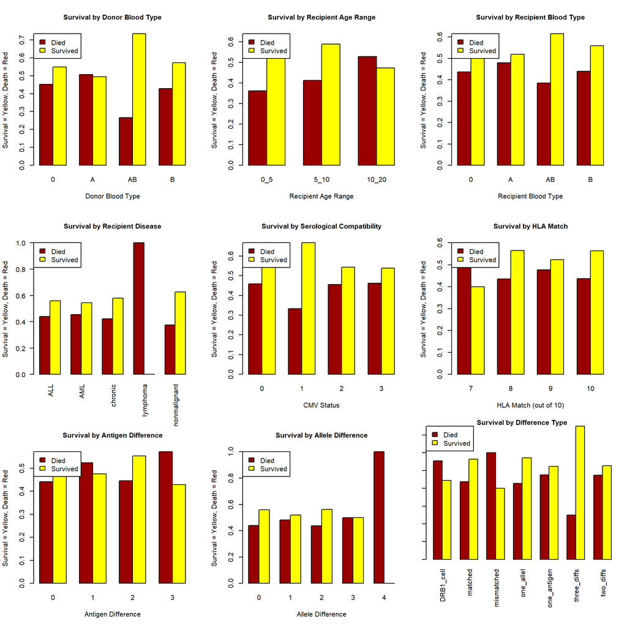

```r
# Increase margin size
par(mar=c(8,1,1,1))

barplot(tab9,
        ylab='Survival = Yellow, Death = Red',
        main="Survival by Difference Type",
        cex.main = 1,
        cex.axis = 0.1,
        las = 2,
        col=c("#990000","yellow"),
        legend=rownames(tab9),
        args.legend=list(x="topleft"), beside=T)
```

#### Binary Variables:

And now, we will take a look at the comparison of our outcome variable and the extensive list of binary variables:

donor_age_below_35 (yes/no), donor_CMV (present/absent), recipient_age_below_10 (yes/no), recipient_rh (plus/minus), recipient_CMV (present/absent), disease_group (malignant/nonmalignant), gender_match(female_to_male/other), ABO_match (matched/mismatched), HLA_mismatch (matched, mismatched), risk_group (high/low), stem_cell_source (peripheral_blood/bone_marrow), tx_post_relapse (yes/no), acute_GvHD_II_III_IV (yes/no), acute_GvHD_III_IV (yes/no), extensive_chronic_GvHD (yes/no), relapse (yes/no), survival_status (yes,no)

```r
par(mfrow = c(4,4))

#Donor Age Group
#2x2 table with margins
tab10 <- table(bone$survival_status,bone$donor_age_below_35)
tab10 <- prop.table(tab10,2)
addmargins(tab10) %>% pander(caption = "Donor Age below 35")
```

Donor Age below 35

|  | no | yes | Sum |
| --- | --- | --- | --- |
| **Died** | 0.5181 | 0.4038 | 0.9219 |
| **Survived** | 0.4819 | 0.5962 | 1.078 |
| **Sum** | 1 | 1 | 2 |

```r
barplot(tab10,
        xlab='Donor Age Under 35',
        ylab='Survival = Yellow, Death = Red',
        main="Survival by Donor Age Range",
        cex.main=1,
        col=c("#990000","yellow"),
        legend=rownames(tab10),
        args.legend=list(x="bottomleft"), beside=T)


#Donor CMV
#2x2 table with margins
tab11 <- table(bone$survival_status,bone$donor_CMV)
tab11 <- prop.table(tab11,2)
addmargins(tab11)  %>% pander(caption = "Donor CMV")
```

Donor CMV

|  | absent | present | Sum |
| --- | --- | --- | --- |
| **Died** | 0.4779 | 0.4167 | 0.8945 |
| **Survived** | 0.5221 | 0.5833 | 1.105 |
| **Sum** | 1 | 1 | 2 |

```r
barplot(tab11,
        xlab='Donor CMV Status',
        ylab='Survival = Yellow, Death = Red',
        main="Survival by Donor CMV Status",
        cex.main=1,
        col=c("#990000","yellow"),
        legend=rownames(tab11),
        args.legend=list(x="bottomleft"), beside=T)


#recipient_age_below_10
#2x2 table with margins
tab12 <- table(bone$survival_status,bone$recipient_age_below_10)
tab12 <- prop.table(tab12,2)
addmargins(tab12)  %>% pander(caption = "Recipient Age Below 10 yrs old")
```

Recipient Age Below 10 yrs old

|  | no | yes | Sum |
| --- | --- | --- | --- |
| **Died** | 0.5341 | 0.3838 | 0.9179 |
| **Survived** | 0.4659 | 0.6162 | 1.082 |
| **Sum** | 1 | 1 | 2 |

```r
barplot(tab12,
        xlab='Recipient Age Below 10',
        ylab='Survival = Yellow, Death = Red',
        main="Survival by Recipient Age Range",
        cex.main=1,
        col=c("#990000","yellow"),
        legend=rownames(tab12),
        args.legend=list(x="bottomleft"), beside=T)

#recipient_rh
#2x2 table with margins
tab13 <- table(bone$survival_status,bone$recipient_rh)
tab13 <- prop.table(tab13,2)
addmargins(tab13)  %>% pander(caption = "Recipient RH Status")
```

Recipient RH Status

|  | minus | plus | Sum |
| --- | --- | --- | --- |
| **Died** | 0.2963 | 0.4747 | 0.771 |
| **Survived** | 0.7037 | 0.5253 | 1.229 |
| **Sum** | 1 | 1 | 2 |

```r
barplot(tab13,
        xlab='Recipient Rh Presence',
        ylab='Survival = Yellow, Death = Red',
        main="Survival by Recipient rh Presence",
        cex.main=1,
        col=c("#990000","yellow"),
        legend=rownames(tab13),
        args.legend=list(x="bottomleft"), beside=T)


#recipient_CMV
#2x2 table with margins
tab14 <- table(bone$survival_status,bone$recipient_CMV)
tab14 <- prop.table(tab14,2)
addmargins(tab14) %>% pander(caption = "Recipient CMV Stautus")
```

Recipient CMV Stautus

|  | absent | present | Sum |
| --- | --- | --- | --- |
| **Died** | 0.411 | 0.45 | 0.861 |
| **Survived** | 0.589 | 0.55 | 1.139 |
| **Sum** | 1 | 1 | 2 |

```r
barplot(tab14,
        xlab='Recipient CMV Presence',
        ylab='Survival = Yellow, Death = Red',
        main="Survival by Recipient CMV Presence",
        cex.main=1,
        col=c("#990000","yellow"),
        legend=rownames(tab14),
        args.legend=list(x="bottomleft"), beside=T)


#disease_group
#2x2 table with margins
tab15 <- table(bone$survival_status,bone$disease_group)
tab15 <- prop.table(tab15,2)
addmargins(tab15)  %>% pander(caption = "Disease Group")
```

Disease Group

|  | malignant | nonmalignant | Sum |
| --- | --- | --- | --- |
| **Died** | 0.471 | 0.375 | 0.846 |
| **Survived** | 0.529 | 0.625 | 1.154 |
| **Sum** | 1 | 1 | 2 |

```r
barplot(tab15,
        xlab='Disease Group',
        ylab='Survival = Yellow, Death = Red',
        main="Survival by Disease Group",
        col=c("#990000","yellow"),
        cex.main=1,
        legend=rownames(tab15),
        args.legend=list(x="bottomleft"), beside=T)


#gender_match
#2x2 table with margins
tab16 <- table(bone$survival_status,bone$gender_match)
tab16 <- prop.table(tab16,2)
addmargins(tab16)  %>% pander(caption = "Gender Match")
```

Gender Match

|  | female_to_male | other | Sum |
| --- | --- | --- | --- |
| **Died** | 0.4688 | 0.4516 | 0.9204 |
| **Survived** | 0.5312 | 0.5484 | 1.08 |
| **Sum** | 1 | 1 | 2 |

```r
barplot(tab16,
        xlab='Gender Match',
        ylab='Survival = Yellow, Death = Red',
        main="Survival by Gender Match?",
        cex.main=1,
        col=c("#990000","yellow"),
        legend=rownames(tab16),
        args.legend=list(x="bottomleft"), beside=T)


#ABO_match
#2x2 table with margins
tab17 <- table(bone$survival_status,bone$ABO_match)
tab17 <- prop.table(tab17,2)
addmargins(tab17)  %>% pander(caption = "Blood Type Match")
```

Blood Type Match

|  | matched | mismatched | Sum |
| --- | --- | --- | --- |
| **Died** | 0.5192 | 0.4254 | 0.9446 |
| **Survived** | 0.4808 | 0.5746 | 1.055 |
| **Sum** | 1 | 1 | 2 |

```r
barplot(tab17,
        xlab='Match based on Blood Group',
        ylab='Survival = Yellow, Death = Red',
        main="Survival by Match of Blood Group",
        col=c("#990000","yellow"),
        cex.main=1,
        legend=rownames(tab17),
        args.legend=list(x="bottomleft"), beside=T)



#HLA_match
#2x2 table with margins
tab18 <- table(bone$survival_status,bone$HLA_mismatch)
tab18 <- prop.table(tab18,2)
addmargins(tab18)  %>% pander(caption = "HLA Mismatch")
```

HLA Mismatch

|  | matched | mismatched | Sum |
| --- | --- | --- | --- |
| **Died** | 0.4528 | 0.4643 | 0.9171 |
| **Survived** | 0.5472 | 0.5357 | 1.083 |
| **Sum** | 1 | 1 | 2 |

```r
barplot(tab18,
        xlab='Match based on HLA',
        ylab='Survival = Yellow, Death = Red',
        main="Survival by Match of HLA",
        cex.main=1,
        col=c("#990000","yellow"),
        legend=rownames(tab18),
        args.legend=list(x="bottomleft"), beside=T)



#risk_group
#2x2 table with margins
tab19 <- table(bone$survival_status,bone$risk_group)
tab19 <- prop.table(tab19,2)
addmargins(tab19)  %>% pander(caption = "Recipient Risk Group")
```

Recipient Risk Group

|  | high | low | Sum |
| --- | --- | --- | --- |
| **Died** | 0.5507 | 0.3983 | 0.949 |
| **Survived** | 0.4493 | 0.6017 | 1.051 |
| **Sum** | 1 | 1 | 2 |

```r
barplot(tab19,
        xlab='Risk Group',
        ylab='Survival = Yellow, Death = Red',
        main="Survival by Risk Group",
        cex.main=1,
        col=c("#990000","yellow"),
        legend=rownames(tab19),
        args.legend=list(x="bottomleft"), beside=T)


#stem_cell_source
#2x2 table with margins
tab20 <- table(bone$survival_status,bone$stem_cell_source)
tab20 <- prop.table(tab20,2)
addmargins(tab20)  %>% pander(caption = "Stem Cell Source")
```

Stem Cell Source

|  | bone_marrow | peripheral_blood | Sum |
| --- | --- | --- | --- |
| **Died** | 0.5714 | 0.4207 | 0.9921 |
| **Survived** | 0.4286 | 0.5793 | 1.008 |
| **Sum** | 1 | 1 | 2 |

```r
barplot(tab20,
        xlab='Stem Cell Source',
        ylab='Survival = Yellow, Death = Red',
        main="Survival by Stem Cell Source",
        cex.main=1,
        col=c("#990000","yellow"),
        legend=rownames(tab20),
        args.legend=list(x="bottomleft"), beside=T)



#tx_post_relapse
#2x2 table with margins
tab21 <- table(bone$survival_status,bone$tx_post_relapse)
tab21 <- prop.table(tab21,2)
addmargins(tab21)  %>% pander(caption = "Treatment after 1st relapse")
```

Treatment after 1st relapse

|  | no | yes | Sum |
| --- | --- | --- | --- |
| **Died** | 0.4329 | 0.6087 | 1.042 |
| **Survived** | 0.5671 | 0.3913 | 0.9584 |
| **Sum** | 1 | 1 | 2 |

```r
barplot(tab21,
        xlab='Treatment After Relapse',
        ylab='Survival = Yellow, Death = Red',
        main="Survival by Treatment(2) after 1st Relapse",
        cex.main=1,
        col=c("#990000","yellow"),
        legend=rownames(tab21),
        args.legend=list(x="bottomleft"), beside=T)



#acute_GvHD_II_III_IV
#2x2 table with margins
tab22 <- table(bone$survival_status,bone$acute_GvHD_II_III_IV)
tab22 <- prop.table(tab22,2)
addmargins(tab22)  %>% pander(caption = "Acute GVHD Stage")
```

Acute GVHD Stage

|  | no | yes | Sum |
| --- | --- | --- | --- |
| **Died** | 0.4133 | 0.4821 | 0.8955 |
| **Survived** | 0.5867 | 0.5179 | 1.105 |
| **Sum** | 1 | 1 | 2 |

```r
barplot(tab22,
        xlab='Development of Acute GVHD stage II, III or IV ',
        ylab='Survival = Yellow, Death = Red',
        main="Survival by Acute GVHD (Stage II, III or IV)",
        col=c("#990000","yellow"),
        cex.main=1,
        legend=rownames(tab22),
        args.legend=list(x="bottomleft"), beside=T)



#acute_GvHD_III_IV
#2x2 table with margins
tab23 <- table(bone$survival_status,bone$acute_GvHD_III_IV)
tab23 <- prop.table(tab22,2)
addmargins(tab23)  %>% pander(caption = "ACUTE GcVD stage III or IV")
```

ACUTE GcVD stage III or IV

|  | no | yes | Sum |
| --- | --- | --- | --- |
| **Died** | 0.4133 | 0.4821 | 0.8955 |
| **Survived** | 0.5867 | 0.5179 | 1.105 |
| **Sum** | 1 | 1 | 2 |

```r
barplot(tab23,
        xlab='Development of Acute GVHD stage III or IV ',
        ylab='Survival = Yellow, Death = Red',
        main="Survival by Acute GVHD (Stage III or IV)",
        col=c("#990000","yellow"),
        cex.main=1,
        legend=rownames(tab23),
        args.legend=list(x="bottomleft"), beside=T)



#extensive_chronic_GvHD
#2x2 table with margins
tab24 <- table(bone$survival_status,bone$extensive_chronic_GvHD)
tab24 <- prop.table(tab24,2)
addmargins(tab24)  %>% pander(caption = "Chronic GvHD")
```

Chronic GvHD

|  | no | yes | Sum |
| --- | --- | --- | --- |
| **Died** | 0.2891 | 0.6071 | 0.8962 |
| **Survived** | 0.7109 | 0.3929 | 1.104 |
| **Sum** | 1 | 1 | 2 |

```r
barplot(tab24,
        xlab='Development of Chronic Acute GVHD',
        ylab='Survival = Yellow, Death = Red',
        main="Survival by Chronic Acute GVHD",
        col=c("#990000","yellow"),
        cex.main=1,
        legend=rownames(tab24),
        args.legend=list(x="bottomleft"), beside=T)



#relapse
#2x2 table with margins
tab25 <- table(bone$survival_status,bone$relapse)
tab25 <- prop.table(tab25,2)
addmargins(tab25) %>% pander(caption = "Relapse")
```

Relapse

|  | no | yes | Sum |
| --- | --- | --- | --- |
| **Died** | 0.3899 | 0.8214 | 1.211 |
| **Survived** | 0.6101 | 0.1786 | 0.7886 |
| **Sum** | 1 | 1 | 2 |

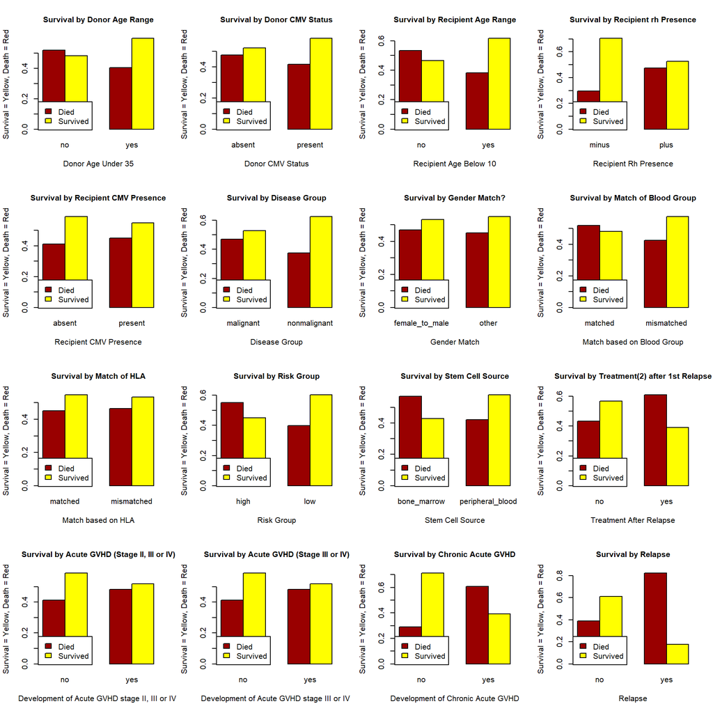

```r
barplot(tab25,xlab='Relapse',
        ylab='Survival = Yellow, Death = Red',
        main="Survival by Relapse",
        cex.main=1,
        col=c("#990000","yellow"),
        legend=rownames(tab25),
        args.legend=list(x="bottomleft"),beside=T)
```

Looking at these resulting graphs and tables we see some interesting relationships that we will want to explore further. Starting with our first comparison:

1. donor_age_below_35 (yes/no) - There was a slightly better chance of survival if the donor was below 35 years old compared to if the donor was above 35 years old

(2)donor_CMV (present/absent) - Not a huge association of survival status with the presence versus the absence of CMV in the donor

3. recipient_age_below_10 (yes/no) - We saw here that there was a slightly increased chance of survival of the recipient was under 10 years old compared to the recipient being under 10 years old
4. recipient_rh (plus/minus) - We found a large association with positive survival chances if the recipient had a minus rh presence compared to a plus rh presence (ex: blood type O- or AB- vs. O+)

(5)recipient_CMV (present/absent) - Not a huge association of survival status with the presence or absence of CMV in the recipient

(6)disease_group (malignant/nonmalignant) - In these plots we see having a nonmalignant disease had a better chance of survival than a malignant disease